# A manual for the use of the RCM functions

Stijn Hawinkel

November 03, 2017

```r
knitr::opts_chunk$set(cache = TRUE, autodep = TRUE,  warning=FALSE, message=FALSE, echo=TRUE, eval=TRUE, tidy = TRUE, fig.width = 9, fig.height = 6, purl=TRUE, fig.show = "hold", cache.lazy = FALSE)
# The required package list:
reqpkg <- c("phyloseq","MASS", "parallel","nleqslv", "edgeR", "ggplot2", "alabama", "reshape2", "tensor", "VGAM", "vegan")
# Load all required packages and show version
for(i in reqpkg)
{
  print(i)
  print(packageVersion(i))
  library(i, quietly=TRUE, verbose=FALSE, warn.conflicts=FALSE, character.only=TRUE)
}
```

```
## [1] "phyloseq"
## [1] '1.20.0'
## [1] "MASS"
## [1] '7.3.47'
## [1] "parallel"
## [1] '3.4.2'
## [1] "nleqslv"
## [1] '3.2'
## [1] "edgeR"
## [1] '3.18.1'
## [1] "ggplot2"
## [1] '2.2.1'
## [1] "alabama"
## [1] '2015.3.1'
## [1] "reshape2"
## [1] '1.4.2'
## [1] "tensor"
## [1] '1.5'
## [1] "VGAM"
## [1] '1.0.3'
## [1] "vegan"
## [1] '2.4.3'
```

```r
palStore = palette()
funFiles = dir("R")
for (i in funFiles) {source(file.path("R",i))} # Run all fitting functions
```

## Dataset

As example data we use a study on the microbiome of colorectal cancer patients “Potential of fecal microbiota for early-stage detection of colorectal cancer” (2014) by Zeller *et al.*.

```r
# Download the necessary files
for (i in c("data", "results")) {
    if (!dir.exists(i))
        dir.create(i)
}
download.file("http://users.ugent.be/~shawinke/data/species.txt", destfile = "./data/species.txt")
download.file("http://users.ugent.be/~shawinke/data/cancer_metadata.txt", destfile = "./data/cancer_metadata.txt")
zellerMeta = read.table("./data/cancer_metadata.txt", header = TRUE, sep = "")  #Read in the patient metadata
zellerS = read.table("./data/species.txt", header = TRUE, sep = "\t", row.names = 1)  #The 16S count data
```

Although our package does accept count matrices, we recommend merging all the data into a *phyloseq* object fro RCM fitting.

```r
Sotu = otu_table(round(zellerS[-1, ]), taxa_are_rows = TRUE)  #Round to integers
Smeta = sample_data(zellerMeta)
rownames(Smeta) = gsub("-", ".", Smeta$Sample)
zellerSphy = phyloseq(Smeta, Sotu)  #Create the phyloseq object
```

## Unconstrained RCM

The unconstrained RC(M) method represents all variability present in the data, regardless of covariate information. It should be used as a first step in an exploratory analysis. We fit a model with two dimensions, which takes a few minutes.

```r
if (!file.exists(file = "./results/ZellerRCM2.RData")) {
    ZellerRCM2 = RCM(zellerSphy, k = 2)
    save(ZellerRCM2, file = "./results/ZellerRCM2.RData")
} else {
    load(file = "./results/ZellerRCM2.RData")
}
```

The runtime was 0.8 minutes to be exact. We plot the result of this ordination in a biplot, beginning with the samples.

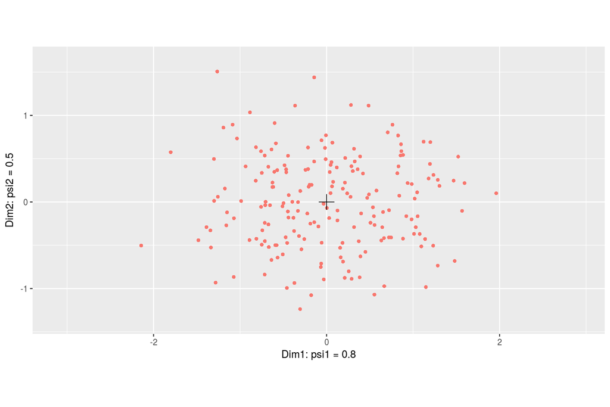

```r
plot(ZellerRCM2, plotType = "samples")
```

No clear signal is present at first sight. Note also that the plot is rectangular according to the values of the importance parameters $\psi$. In order to truthfully represent the distances between samples all axis must be on the same scale. We can add a colour code for the cancer diagnosis contained in the phyloseq object.

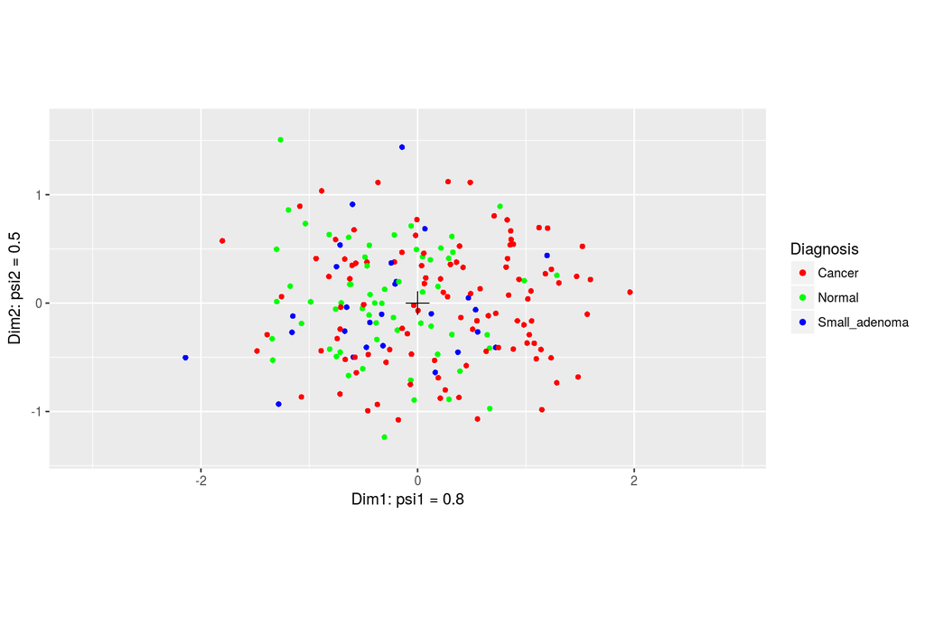

```r
plot(ZellerRCM2, plotType = "samples", samColour = "Diagnosis")
```

It is clear that some of the variability of the samples is explained by the cancer status of the patients.

Next we plot only the species.

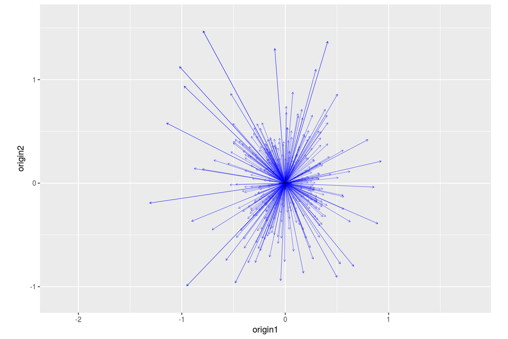

```r
plot(ZellerRCM2, plotType = "species")
```

The researchers found that species from the Fusobacteria genus are associated with cancer. We can plot only these species using a regular expression.

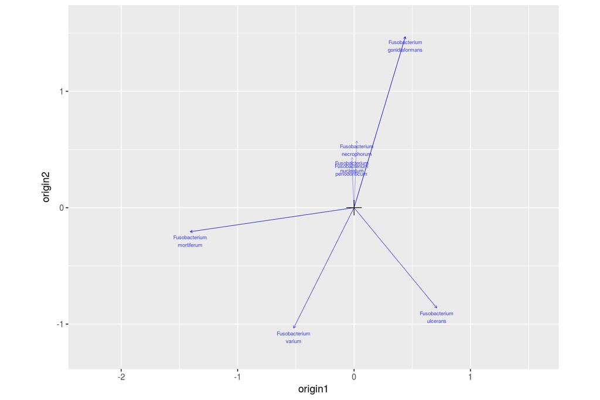

```r
plot(ZellerRCM2, plotType = "species", taxRegExp = "Fusobacter", taxLabels = TRUE)
```

It is clear that these Fusobacterium species behave very differently between the species.

Finally we can combine both plots into an interpretable biplot, which is the default for unconstrained RC(M). To avoid overplotting we only show the taxa with the 10 most important departures from independence.

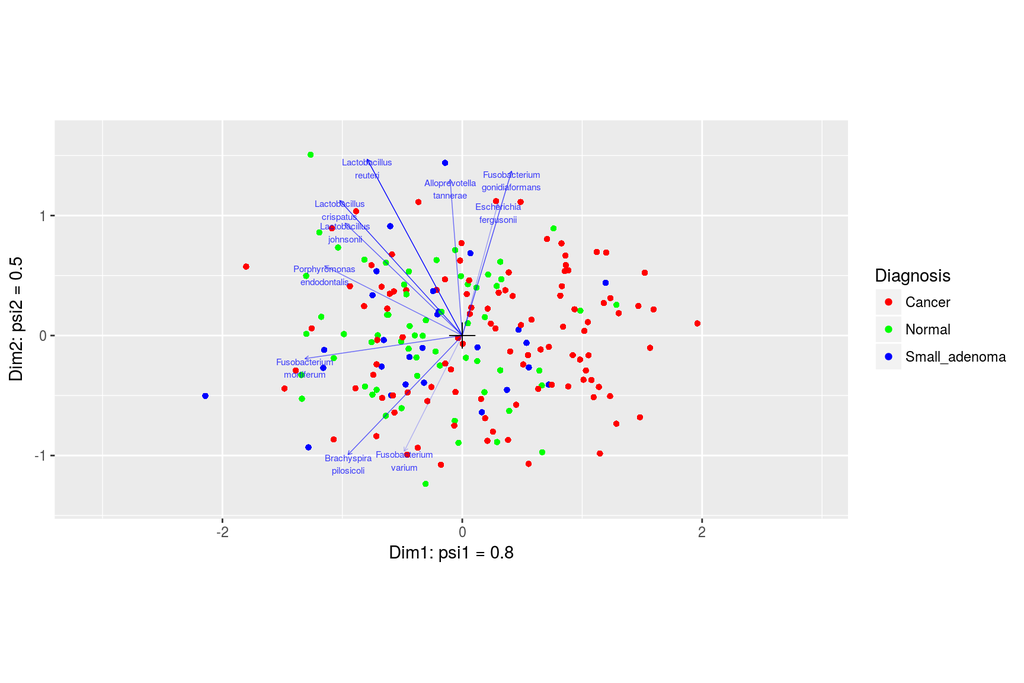

```r
plot(ZellerRCM2, taxNum = 10, samColour = "Diagnosis")
```

Samples are represented by dots, taxa by arrows. Both represent vectors with the origin as starting point.

Distances between endpoints of taxon vectors are meaningless.

### Adding dimensions

Since the model is fitted dimension per dimension, we only have information on the first two dimension. If we want to add a third dimension, we do not have to start from scratch but can use the previously fitted model in two dimension as a starting point and additionally estimate the third dimension.

```r
if (!file.exists(file = "./results/ZellerRCM3.RData")) {
    ZellerRCM3 = RCM(zellerSphy, prevFit = ZellerRCM2, k = 3)
    save(ZellerRCM3, file = "./results/ZellerRCM3.RData")
} else {
    load(file = "./results/ZellerRCM3.RData")
}
```

The total runtime for all dimensions combined was 2.3. We can then plot any combination of two dimensions we want, e.g. the first and the third.

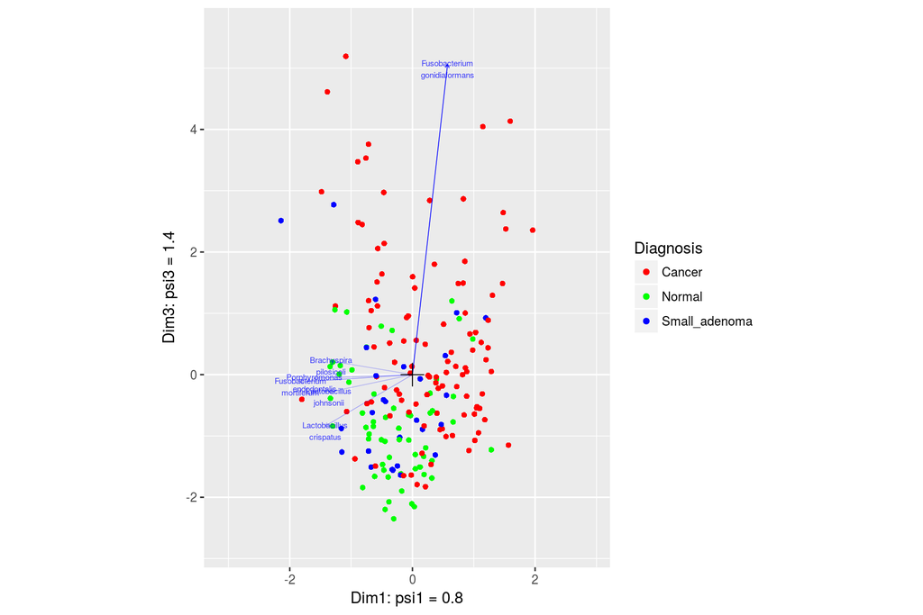

```r
plot(ZellerRCM3, Dim = c(1, 3), samColour = "Diagnosis", taxNum = 6)
```

The third dimension also correlates with a separation of cancer patients vs. healthy and small adenoma patients.

### Assessing the goodness of fit

Some taxa (or samples) may not follow a negative binomial distribution, or their departures from independence may not be appropriately represented in low dimensions. We visualize these taxa and samples through their deviances, which are the squared sums of their deviance residuals. This allows us to graphically identify taxa and samples that are poorly represented in the current ordination.

The deviance residuals can be extracted manually

```r
devResiduals = getDevianceRes(ZellerRCM2, Dim = c(1, 2))
```

but you can also just supply the argument “Deviance” to samColour

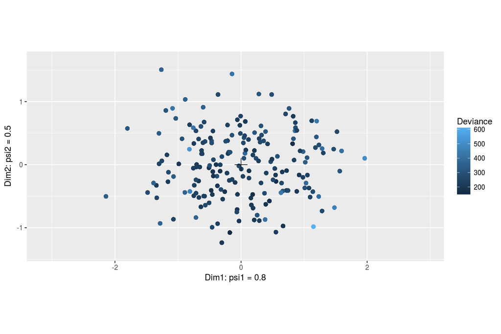

```r
plot(ZellerRCM2, plotType = "samples", samColour = "Deviance", samSize = 2.5)
```

Samples with the largest scores exhibit the poorest fit. This may indicate that samples with strong departures from independence acquire large scores, but still are not well represented in lower dimensions. Especially the one bottom right may be a problematic case.

We again also use the third dimension, maybe this sample is fitted well there?

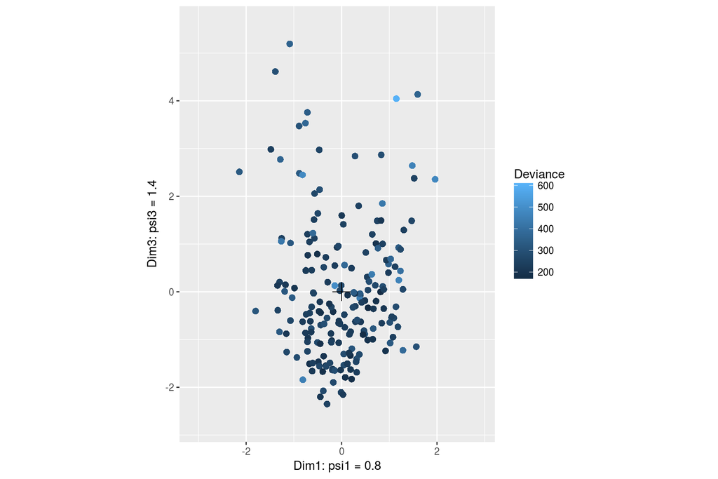

```r
plot(ZellerRCM3, plotType = "samples", samColour = "Deviance", samSize = 2.5,
    Dim = c(1, 3))
```

No the problem persists there.

The same principle can be applied to the taxa

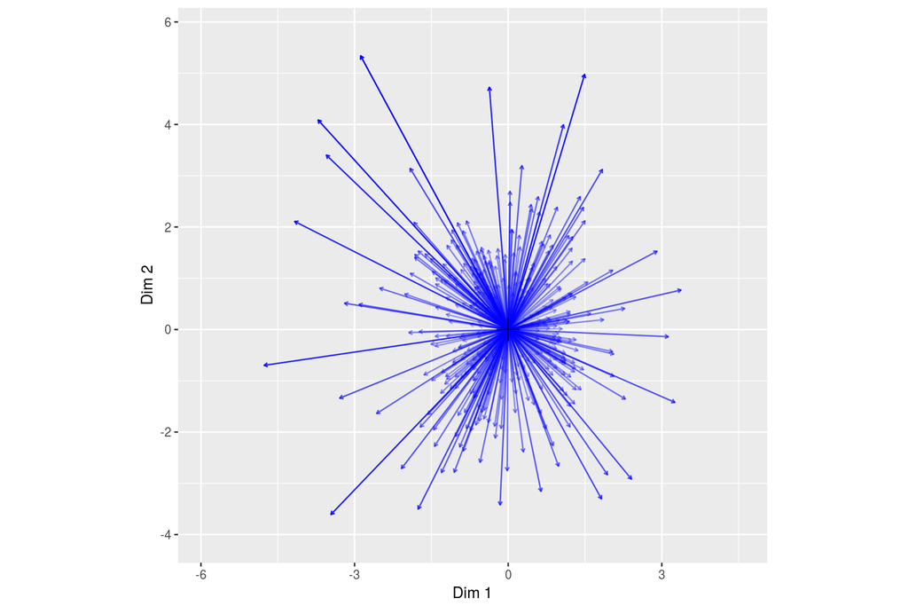

```r
plot(ZellerRCM3, plotType = "species", taxCol = "Deviance", samSize = 2.5, Dim = c(1,
    2), arrowSize = 0.5)
```

For the taxa it appears to be the taxa with smaller scores are the more poorly fitted ones. Note that since the count table is not square, we cannot compare sample and taxon deviances. They have not been calculated based on the same number of taxa. Also, one cannot do chi-squared tests based on the deviances since this is not a classical regression model, but an overparametrized one.

## Constrained analysis

In this second step we look for the variability in the dataset explained by linear combinations of covariates that maximally separate the niches of the species. This should be done in a second step, and preferably only with variables that are believed to have an impact on the species’ abundances. Here we used the variables age, gender, BMI, country and diagnosis in the gradient. In this analysis all covariates values of a sample are projected onto a single scalar, the environmental score of this sample. The projection vector is called the environmental gradient, the magnitude of its components reveals the importance of each variable. The taxon-wise response functions then describe how the logged mean abundance depends on the environmental score.

### Linear response functions

Even though these response functions may be too simplistic, they have the advantage of being easy to interpret (and plot).

```r
if (!file.exists(file = "./results/ZellerRCM2constr.RData")) {
    ZellerRCM2constr = RCM(zellerSphy, k = 2, covariates = c("Age", "Gender",
        "BMI", "Country", "Diagnosis"), responseFun = "linear")
    save(ZellerRCM2constr, file = "./results/ZellerRCM2constr.RData")
} else {
    load(file = "./results/ZellerRCM2constr.RData")
}
```

First we plot the samples

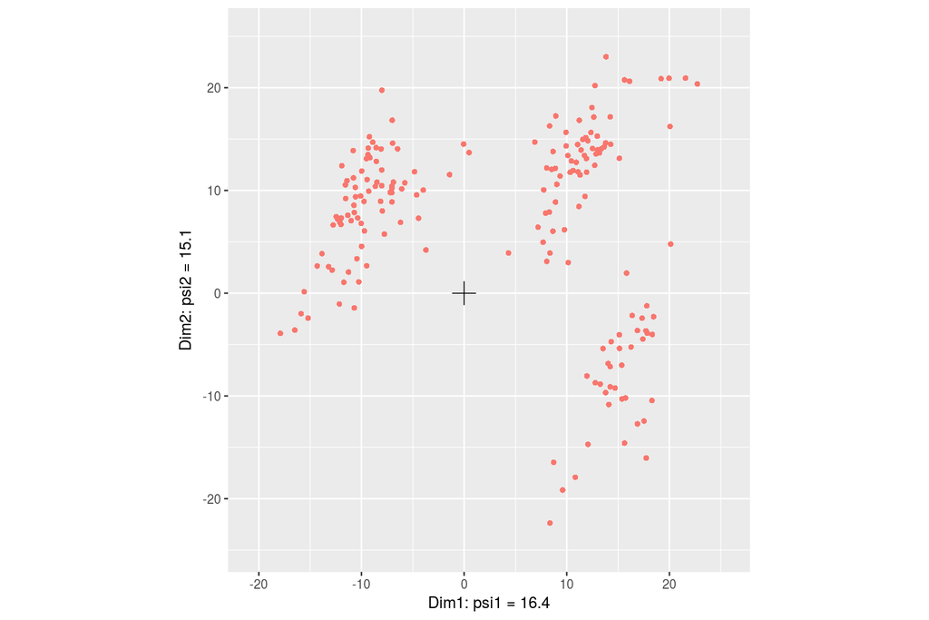

```r
plot(ZellerRCM2constr, plotType = c("samples"))
```

In the constrained analysis we clearly see three groups of samples appearing.

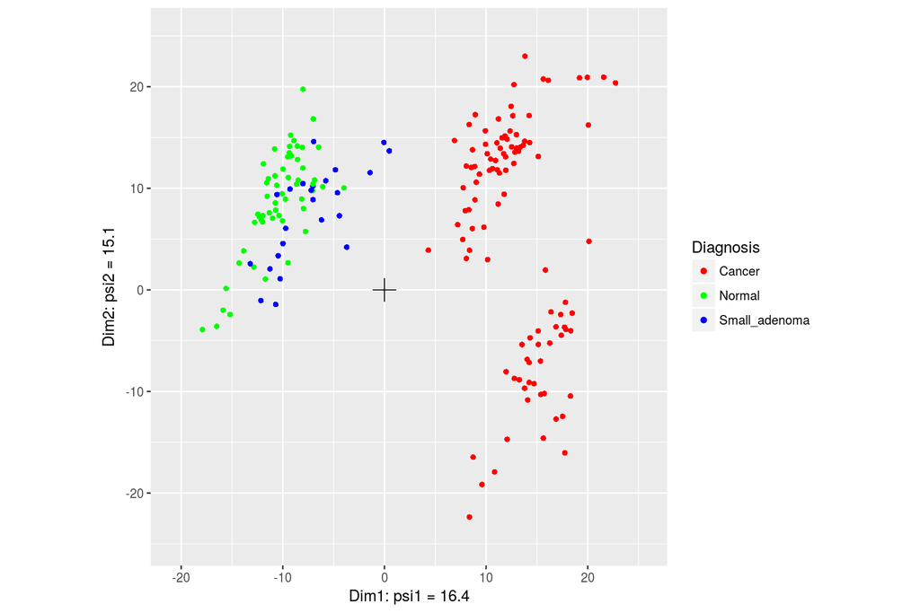

```r
plot(ZellerRCM2constr, plotType = c("samples"), samColour = "Diagnosis")
```

One group are the healthy patients, the other two are cancer patients.

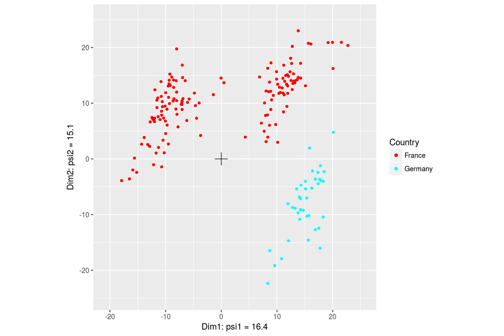

```r
plot(ZellerRCM2constr, plotType = c("samples"), samColour = "Country")
```

The cancer patients are separated by country. Note that from Germany there are only cancer patients in this dataset.

Now we add the species to make a biplot

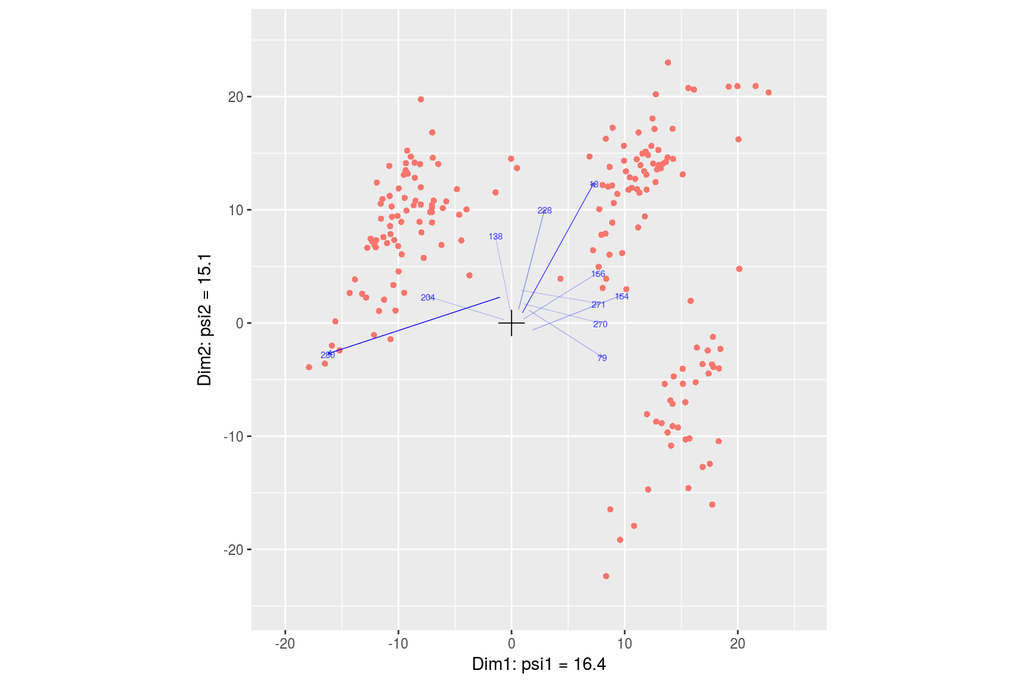

```r
plot(ZellerRCM2constr, plotType = c("species", "samples"))
```

The interpretation is similar as before: the orthogonal projection of a taxon’s arrow on a sample represents the departure from independence for that taxon in that sample, *explained by environmental variables*. New is also that the taxa arrows do not strt from the origin, but all have their own starting point. This starting point represents the environmental scores for which there is no departure from independence. The direction of the arrow then represents how its expected abundance increases.

Next we can make a biplot of taxa and environmental variabless.

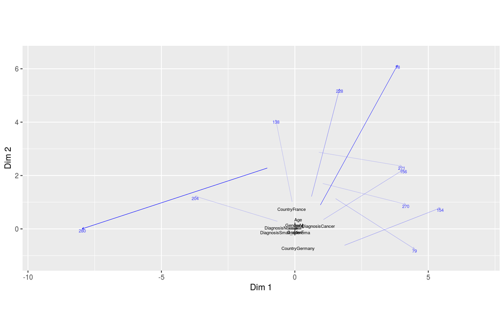

```r
plot(ZellerRCM2constr, plotType = c("species", "variables"))
```

The projection of species arrows on environmental variables (starting from the origin) represents the sensitivity of this taxon to changes in this variables. Note that the fact that the arrows of BMI and gender are of similar lenght indicates that one *standard deviation* in BMI has a similar effect to gender.

We observe that country and diagnosis are the main drivers of the environmental gradient. We also see that healthy patients are very similar to small adenoma patients, but that they are very different from cancer patients.

To finish we also show the triplot, which unites all the information of the ordination:

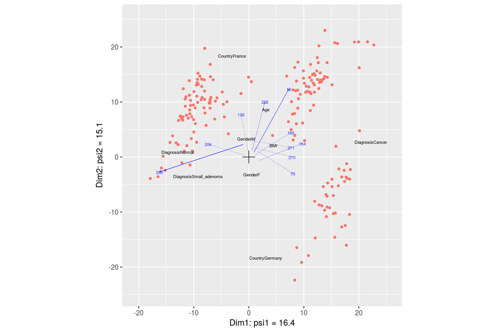

```r
plot(ZellerRCM2constr)
```

Note that the samples and the environmental variables cannot be related to each other.

#### Assessing the goodness of fit

Also for constrained ordination it can be interesting to use the deviance residuals. We can use them in the unconstrained case by summing over taxa or samples, or plot them versus the environmental gradient to detect lack of fit for the shape of the response function. For this latter goal we provide two procedures: a diagnostic plot of the taxa with the strongest response to the environmental gradient, or an automatic trend detection using the runs test statistic by Ward and Wolfowitz. Checking the linearity (or Gaussian) assumption of the response function is crucial: excessive departure invalidate the interpretation of the ordination plot.

A deviance residual plot for the strongest responders

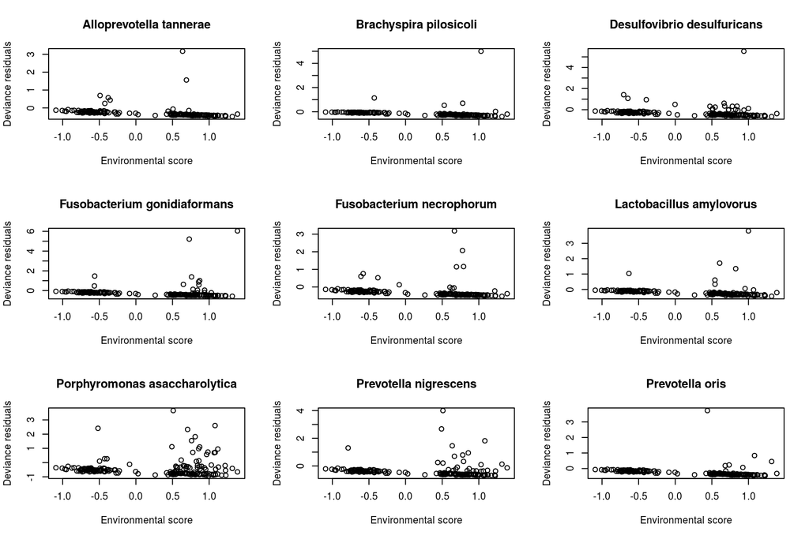

```r
residualPlot(ZellerRCM2constr, whichTaxa = "response")
```

The same taxa but with Pearson residuals

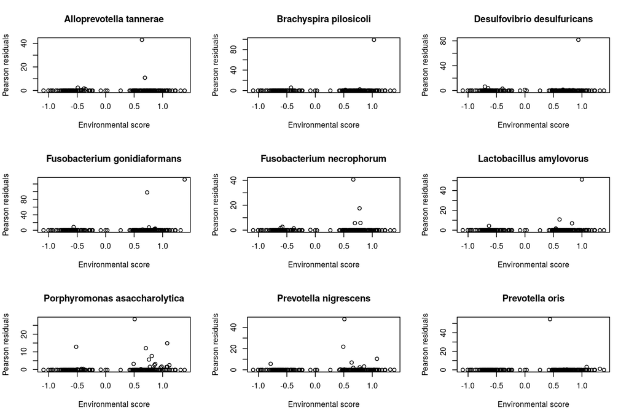

```r
residualPlot(ZellerRCM2constr, whichTaxa = "response", resid = "Pearson")
```

Most species do not exhibit any obvious pattern, although departures seem to increase with environmental scores.

The runs test is a test that automatically attempts to detect non randomness in the sequence of positive and negative residuals. We plot the residual plots for the taxa with the largest run statistic (since the sample sizes and null distributions are equal this corresponds with the smallest p-values, but we do not do inference here because of the non-classical framework).

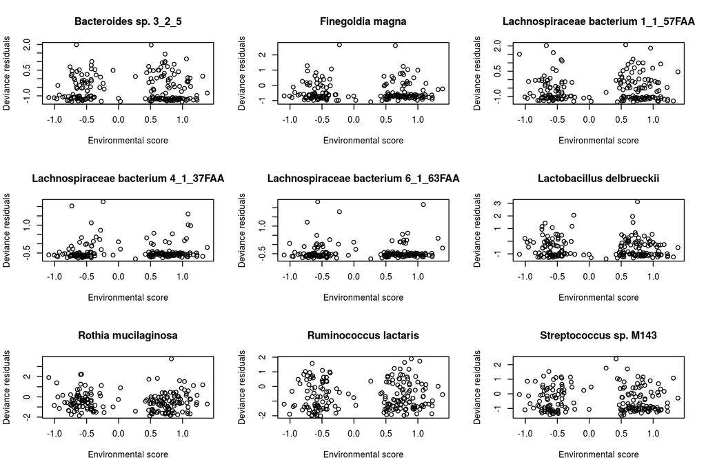

```r
residualPlot(ZellerRCM2constr, whichTaxa = "runs", resid = "Deviance")
```

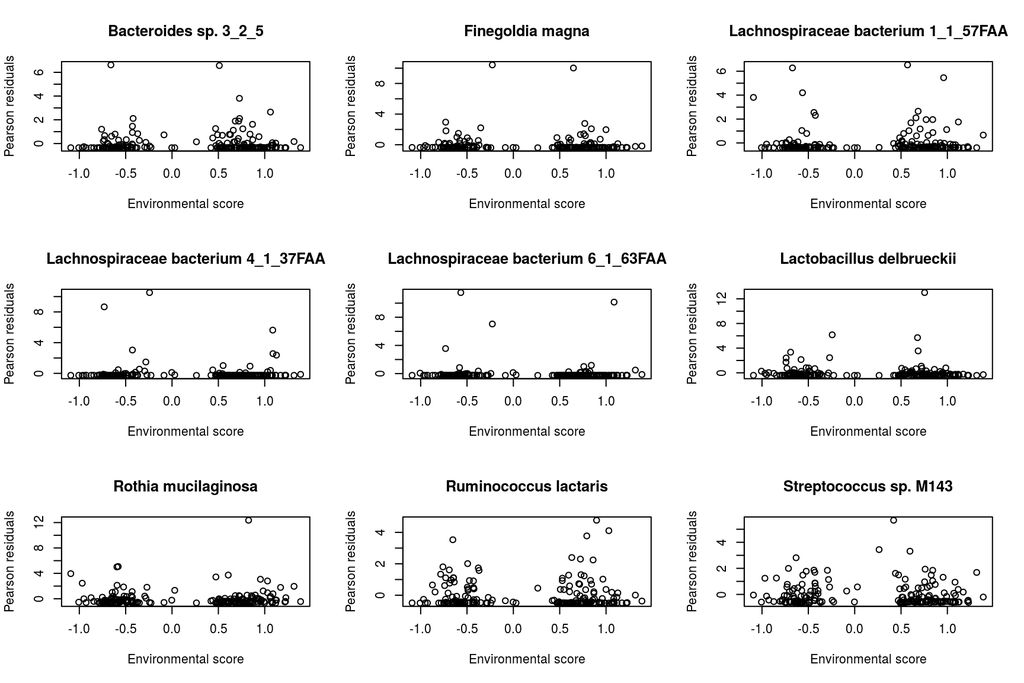

```r
residualPlot(ZellerRCM2constr, whichTaxa = "runs", resid = "Pearson")
```

For these taxa we see no signal at all. The runs test statistic may be dominated by the number of zero counts, and not be informative at all.

#### Identifying influential observations

It can also be interesting to see which samples have the strongest influence on the environmental gradient.

```r
inflArr = NBalphaInfl(ZellerRCM2constr, Dim = 1)
```

Say we want to know which samples have on average the largest influence on the estimation of the age parameter.

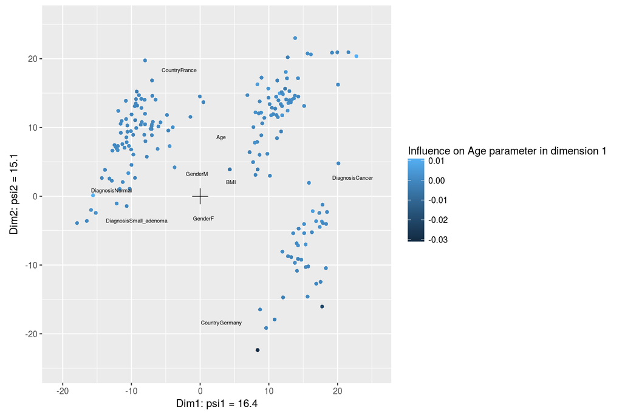

```r
plot(ZellerRCM2constr, plotType = c("variables", "samples"), samColour = rowSums(inflArr[,
    , "Age"]), colLegend = "Influence on Age parameter in dimension 1")
```

Below we see a couple of very influential observations. They may be very young?

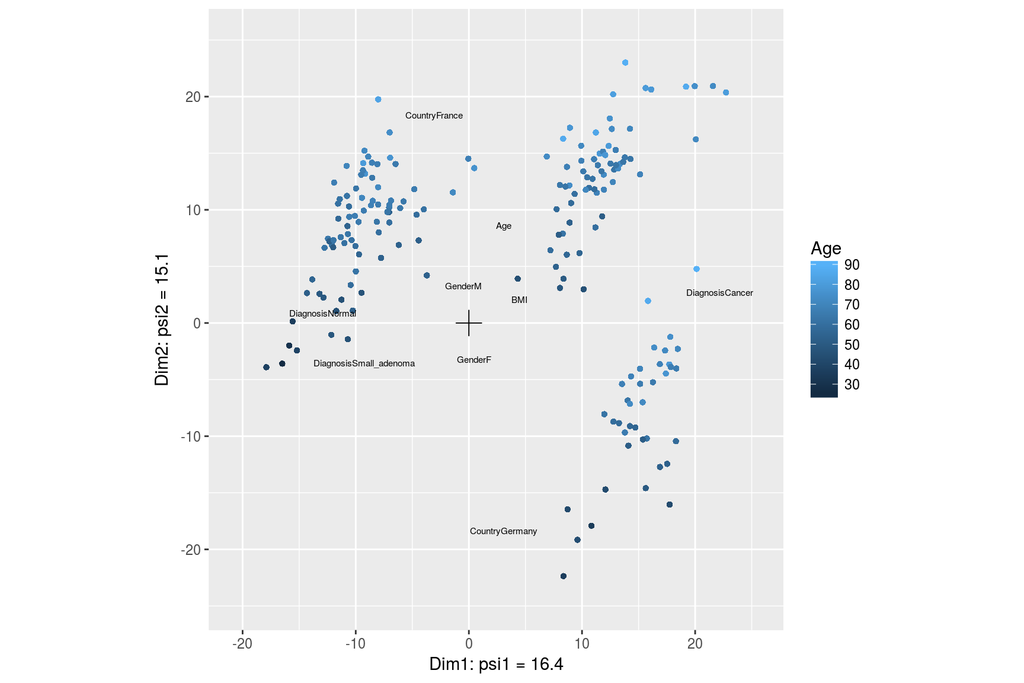

```r
plot(ZellerRCM2constr, plotType = c("variables", "samples"), samColour = "Age")
```

Indeed, a few young subjects affect the estimation of the age parameter most. One should always be wary of these kind of “outliers” that strongly affect the ordination.

We can achieve the same plots by using the “influence” flag in the plotting function.

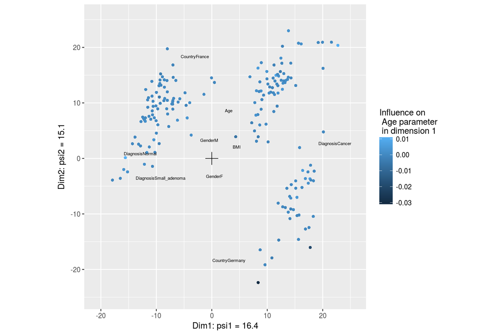

```r
plot(ZellerRCM2constr, plotType = c("variables", "samples"), samColour = "Age",
    Influence = TRUE)
```

The age coefficient is largest in the second dimension actually, let’s look at the influence on that component

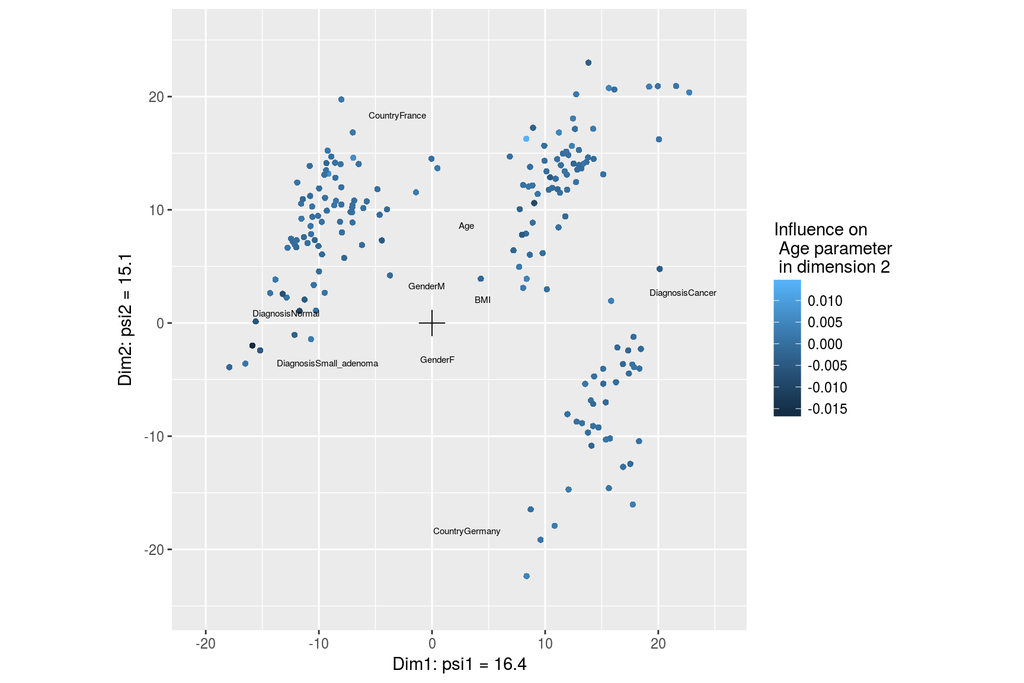

```r
plot(ZellerRCM2constr, plotType = c("variables", "samples"), samColour = "Age",
    Influence = TRUE, inflDim = 2)
```

One last illustration: which samples have the strongest impact on the “DiagnosisCancer” parameter

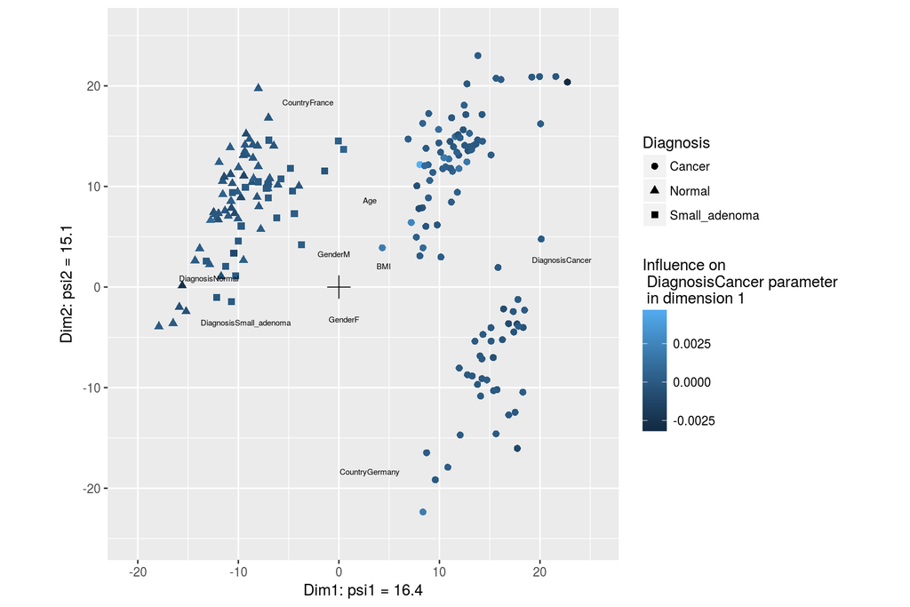

```r
plot(ZellerRCM2constr, plotType = c("variables", "samples"), samColour = "DiagnosisCancer",
    Influence = TRUE, samShape = "Diagnosis", samSize = 2)
```

French cancer patients appear to have the strongest impact.

### Non-parametric response functions

These response functions are very data driven, but have the drawback that they do not allow to visualize the role of the taxa in the ordination.

```r
if (!file.exists(file = "./results/ZellerRCM2constrnonParam.RData")) {
    ZellerRCM2constrNonParam = RCM(zellerSphy, k = 2, covariates = c("Age",
        "Gender", "BMI", "Country", "Diagnosis"), responseFun = "nonparametric")
    save(ZellerRCM2constrNonParam, file = "./results/ZellerRCM2constrNonParam.RData")
} else {
    load(file = "./results/ZellerRCM2constrNonParam.RData")
}
```

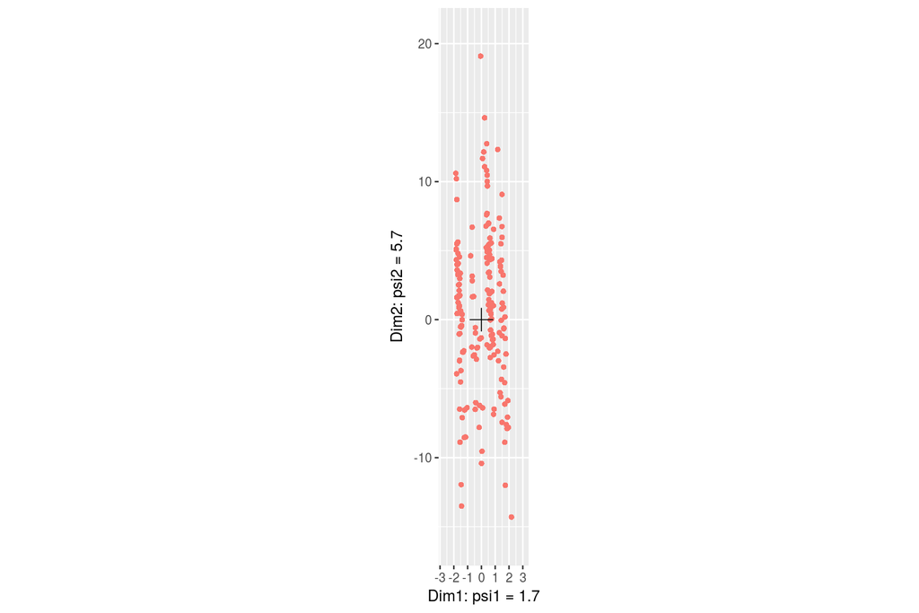

```r
plot(ZellerRCM2constrNonParam, plotType = "samples")
```

Using non-parametric response functions we do not find the same clear clusters

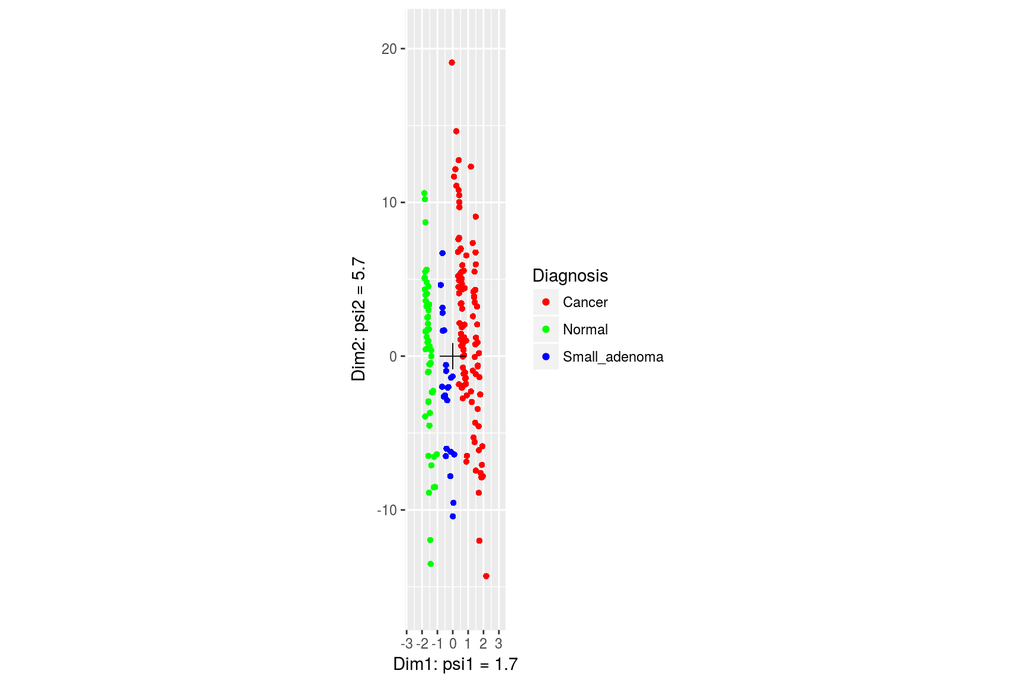

```r
plot(ZellerRCM2constrNonParam, plotType = "samples", samColour = "Diagnosis")
```

Show the variables

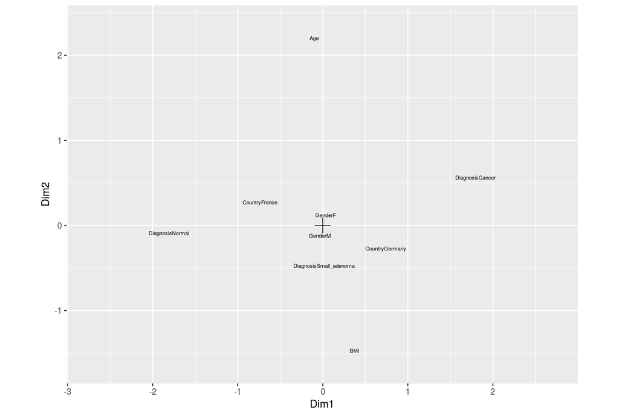

```r
plot(ZellerRCM2constrNonParam, plotType = "variables")
```

The envrionmental gradients are quite different from the case with the linear response functions. Especially age is an important driver of the environmental gradient here. Still the results for cancer diagnosis , country and gender are similar to before.